# simpimp ana - eye-tracking and iPad data

Erica Yoon

February 4, 2016

```r
rm(list = ls())
setwd("/Users/ericang/Documents/Research/simpimp_GIT/")
source("useful.R")
source("et_helper.R")
library(ggplot2)
library(data.table)

d_et <- fread("/Users/ericang/Documents/Research/simpimp_GIT/simpimp_et_all.csv")
```

```
##
Read 0.0% of 3822758 rows
Read 32.2% of 3822758 rows
Read 68.0% of 3822758 rows
Read 3822758 rows and 10 (of 10) columns from 0.287 GB file in 00:00:06
```

```r
head(d_et)
```

```
##       expt     subid       stimulus order trial_type age_group correct
## 1: et_2vs1 140217-02 simpkidsL1.012     1         cs         3    TRUE
## 2: et_2vs1 140217-02 simpkidsL1.012     1         cs         3    TRUE
## 3: et_2vs1 140217-02 simpkidsL1.012     1         cs         3    TRUE
## 4: et_2vs1 140217-02 simpkidsL1.012     1         cs         3    TRUE
## 5: et_2vs1 140217-02 simpkidsL1.012     1         cs         3    TRUE
## 6: et_2vs1 140217-02 simpkidsL1.012     1         cs         3    TRUE
##       t.crit targetAtOnset t.crit.binned
## 1: -6.233667         FALSE        -6.233
## 2: -6.225333         FALSE        -6.233
## 3: -6.217000         FALSE        -6.233
## 4: -6.208667         FALSE        -6.200
## 5: -6.200333         FALSE        -6.200
## 6: -6.192000         FALSE        -6.200
```

```r
d_ip <- fread("/Users/ericang/Documents/Research/simpimp_GIT/simpimp_ipad_short.csv")
d_ip$expt <- "ipad"
head(d_ip)
```

```
##           subid age_group     trial_type item_num correct   rt expt
## 1: 141204-01-sc         3       practice       NA       1 7545 ipad
## 2: 141204-01-sc         3       practice       NA       1 1610 ipad
## 3: 141204-01-sc         3 control_single     2vs2       1 1997 ipad
## 4: 141204-01-sc         3      inference     3vs1       1 1897 ipad
## 5: 141204-01-sc         3 control_double     3vs1       1 3739 ipad
## 6: 141204-01-sc         3 control_single     1vs1       1 1517 ipad
```

# look at distribution of rt for ipad data

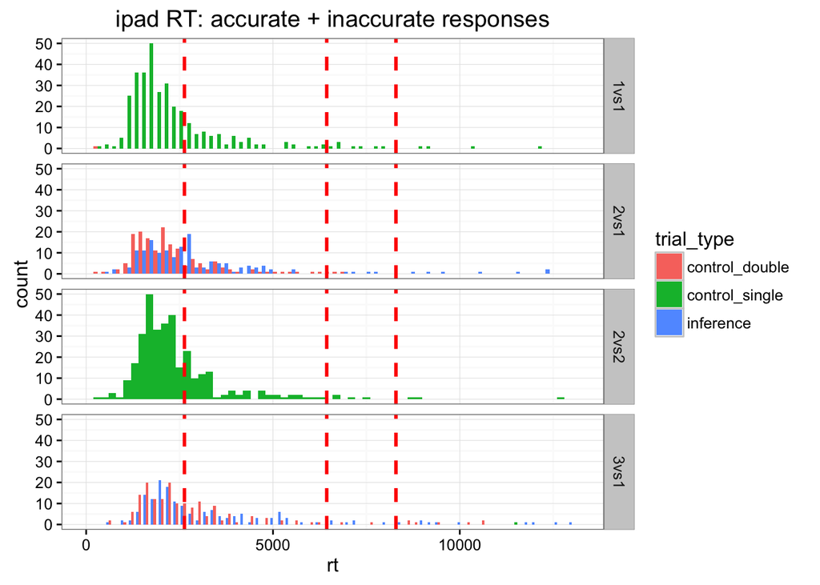

```r
# ipad rt
ggplot(subset(d_ip, trial_type != "practice"), aes(x=rt, fill=trial_type)) +
    geom_histogram(binwidth=200, position="dodge") +
    geom_vline(aes(xintercept=mean(rt, na.rm=T)),   # Ignore NA values for mean
               color="red", linetype="dashed", size=1) +
    geom_vline(aes(xintercept=mean(d_ip$rt) + 2*sd(d_ip$rt, na.rm=TRUE)),   # Ignore NA values for mean
               color="red", linetype="dashed", size=1) +
    geom_vline(aes(xintercept=mean(d_ip$rt) + 3*sd(d_ip$rt, na.rm=TRUE)),   # Ignore NA values for mean
               color="red", linetype="dashed", size=1) +
    facet_grid(item_num~.) +
  ggtitle("ipad RT: accurate + inaccurate responses")
```

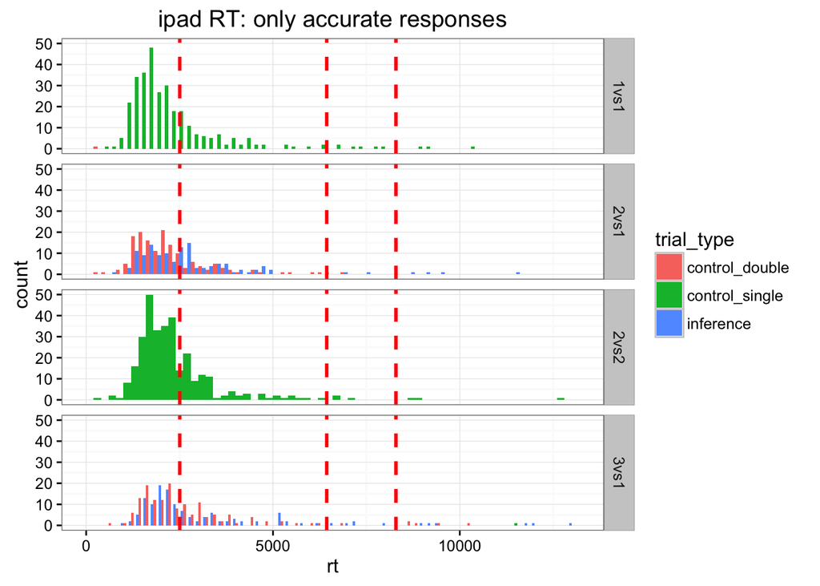

```r
# only accurate
ggplot(subset(d_ip, trial_type != "practice" & correct == TRUE), aes(x=rt, fill=trial_type)) +
    geom_histogram(binwidth=200, position="dodge") +
    geom_vline(aes(xintercept=mean(rt, na.rm=T)),   # Ignore NA values for mean
               color="red", linetype="dashed", size=1) +
    geom_vline(aes(xintercept=mean(d_ip$rt) + 2*sd(d_ip$rt, na.rm=TRUE)),   # Ignore NA values for mean
               color="red", linetype="dashed", size=1) +
    geom_vline(aes(xintercept=mean(d_ip$rt) + 3*sd(d_ip$rt, na.rm=TRUE)),   # Ignore NA values for mean
               color="red", linetype="dashed", size=1) +
    facet_grid(item_num~.) +
  ggtitle("ipad RT: only accurate responses")
```

Similar spread for control and inference trials, across different numbers of items.

Max is within 15 seconds. Cut 3 SD from the mean:

```r
# remove outliers, by rt
dropcrit <- mean(d_ip$rt) + 3*sd(d_ip$rt, na.rm=TRUE)
d_ip <- d_ip %>%
  filter(rt < dropcrit)
```

# look at distribution of rt for eye-tracking data

```r
# et rt
# information on when the first switch was made (distractor -> target or target -> distractor, after word onset)
d_et1 <- d_et %>%
  filter(t.crit > 0) %>%
  filter((targetAtOnset == FALSE & correct == TRUE) | (targetAtOnset == TRUE & correct == FALSE)) %>%
  group_by(subid, stimulus) %>%
  summarize(switch_t = min(t.crit))
d_et <- inner_join(d_et, d_et1)
```

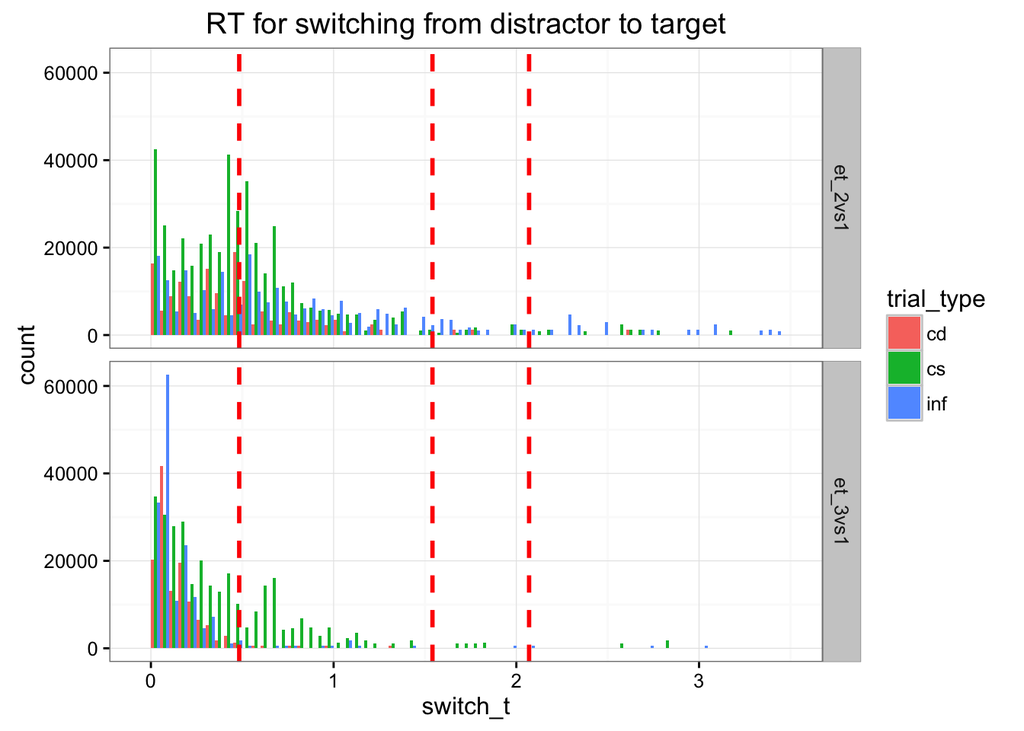

```r
# distribution of rt
ggplot(subset(d_et, targetAtOnset == FALSE), aes(x=switch_t, fill=trial_type)) +
    geom_histogram(binwidth=0.05, position="dodge") +
    geom_vline(aes(xintercept=mean(switch_t, na.rm=T)),   # Ignore NA values for mean
               color="red", linetype="dashed", size=1) +
    geom_vline(aes(xintercept=mean(switch_t) + 2*sd(switch_t, na.rm=TRUE)),   # Ignore NA values for mean
               color="red", linetype="dashed", size=1) +
    geom_vline(aes(xintercept=mean(switch_t) + 3*sd(switch_t, na.rm=TRUE)),   # Ignore NA values for mean
               color="red", linetype="dashed", size=1) +
      facet_grid(expt~.) +
  ggtitle("RT for switching from distractor to target")
```

Very interestingly, rt’s much less spread out for 3-vs-1 experiment, control-double and inference trials. (And a hint of difference between control-single trials in 2-vs-1 vs. 3-vs-1 expt, but not so much?)

Look at the distribution of rt for switching from TARGET to DISTRACTOR too:

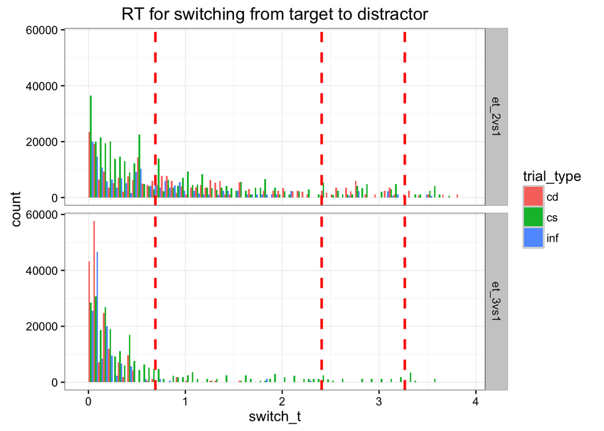

```r
# distribution of rt
ggplot(subset(d_et, targetAtOnset == TRUE), aes(x=switch_t, fill=trial_type)) +
    geom_histogram(binwidth=0.05, position="dodge") +
    geom_vline(aes(xintercept=mean(switch_t, na.rm=T)),   # Ignore NA values for mean
               color="red", linetype="dashed", size=1) +
    geom_vline(aes(xintercept=mean(switch_t) + 2*sd(switch_t, na.rm=TRUE)),   # Ignore NA values for mean
               color="red", linetype="dashed", size=1) +
    geom_vline(aes(xintercept=mean(switch_t) + 3*sd(switch_t, na.rm=TRUE)),   # Ignore NA values for mean
               color="red", linetype="dashed", size=1) +
      facet_grid(expt~.) +
    ggtitle("RT for switching from target to distractor")
```

The same pattern shows up, where the control-single looks similar across the 2 expts but control-double and inference have very quick reaction times.

# eye-tracking

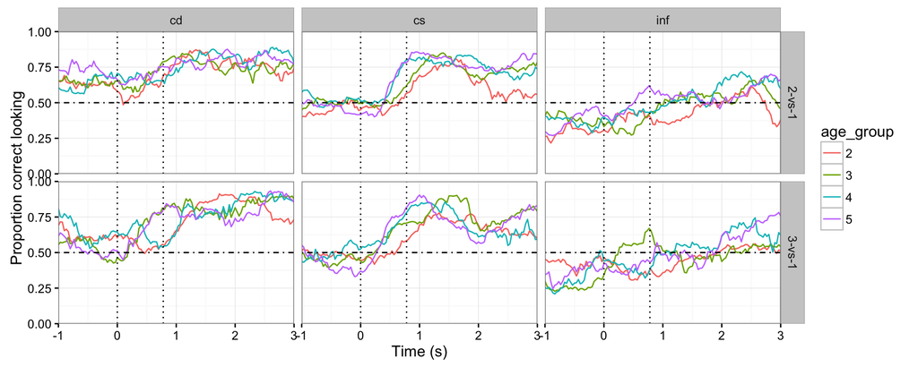

```r
## correct ~ t.crit.binned + trial_type + age_group
mss <- d_et %>%
  filter(age_group == "2" | age_group == "3" | age_group == "4" | age_group == "5" | age_group == "adult") %>%
  # filter(expt == "0") %>%
  filter(t.crit > -1 & t.crit <= 3) %>%
  group_by(expt,trial_type, age_group, t.crit.binned, subid) %>%
  summarise(correct = mean(correct, na.rm = TRUE)) %>%
  ungroup() %>%
  mutate(subid = as.factor(subid),
         age_group = as.factor(age_group),
         age_group = factor(age_group, levels = c("2","3","4", "5", "adult")),
         expt = as.factor(expt))
levels(mss$expt) = c("2-vs-1", "3-vs-1")

ms <- mss %>%
  mutate(trial_type = as.factor(trial_type)) %>%
  group_by(expt, t.crit.binned, trial_type, age_group) %>%
  summarise(correct = mean(correct, na.rm=TRUE))

# compare age groups
p <- ggplot(subset(ms, age_group != "adult"), aes(x = t.crit.binned, y = correct, colour = age_group)) +
  geom_line() +
  facet_grid(expt~trial_type) +
  geom_vline(xintercept=0,lty=3) +
  geom_vline(xintercept=0.78,lty=3) +
  geom_hline(yintercept=.50,lty=4) +
  xlab("Time (s)") + ylab("Proportion correct looking") +
  scale_x_continuous(expand = c(0,0)) +
  scale_y_continuous(limits=c(0,1),expand = c(0,0))
p
```

Children are better at finding the correct answer for control trials than inference. They also get increasingly better at any trials with increasing age.

But there doesn’t seem to be an advantage/disadvantage of having 3 items instead of 2 for the distractor.

What if we compare 2-vs-1 and 3-vs-1 directly, facetting by condition and age-group?

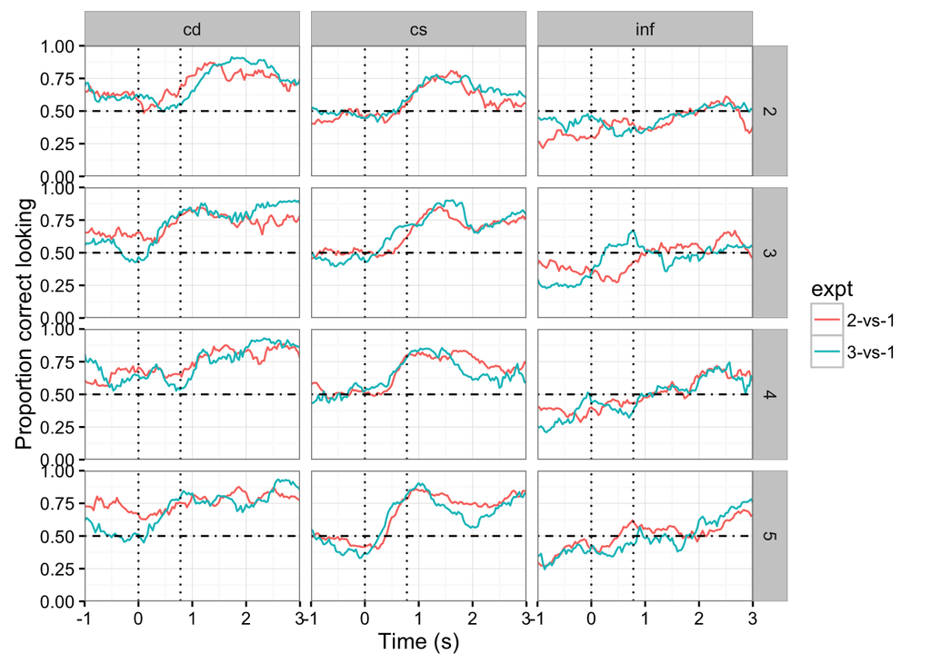

```r
# compare 2-vs-1 vs. 3-vs-1
p <- ggplot(subset(ms, age_group != "adult"), aes(x = t.crit.binned, y = correct, colour = expt)) +
  geom_line() +
  facet_grid(age_group~trial_type) +
  geom_vline(xintercept=0,lty=3) +
  geom_vline(xintercept=0.78,lty=3) +
  geom_hline(yintercept=.50,lty=4) +
  xlab("Time (s)") + ylab("Proportion correct looking") +
  scale_x_continuous(expand = c(0,0)) +
  scale_y_continuous(limits=c(0,1),expand = c(0,0))
p
```

(control-single trials were the same in the two experiments)

There does not seem to be any difference between the two experiments.

## onset-contingency for inference trials

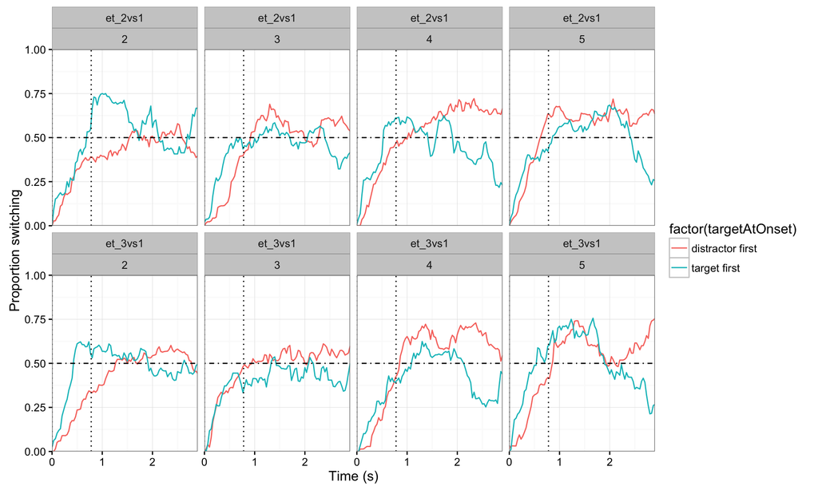

```r
ms <- d_et %>%
  filter(age_group == "2" | age_group == "3" | age_group == "4" | age_group == "5") %>%
  filter(trial_type == "inf") %>%
  group_by(expt, age_group, targetAtOnset, t.crit.binned) %>%
  summarize(correct = mean(correct, na.rm=TRUE)) %>%
  filter(targetAtOnset != "NA") %>%
  ungroup() %>%
  mutate(targetAtOnset = as.numeric(targetAtOnset),
         correct = ifelse(targetAtOnset==1, 1-correct, correct),
         targetAtOnset = as.factor(targetAtOnset),
         age_group = factor(age_group, levels = c("2","3","4", "5", "adult")))

levels(ms$targetAtOnset) <- c("distractor first", "target first")

qplot(as.numeric(as.character(t.crit.binned)),correct,
      colour=factor(targetAtOnset),
      geom="line", #lty=factor(targetAtOnset), # alpha=.5,
      data=ms) +
  facet_wrap(expt~age_group, ncol=4) +
  scale_fill_brewer(palette="Set1") +
  geom_hline(yintercept=.5,lty=4) +
  geom_vline(xintercept=.78,lty=3) +
  geom_vline(xintercept=0,lty=3) +
  scale_y_continuous(expand = c(0, 0), limits=c(0,20)) +
  xlab("Time (s)") + ylab("Proportion switching") +
  scale_x_continuous(limits=c(0,2.9),expand = c(0,0)) +
  scale_y_continuous(limits=c(0,1),expand = c(0,0)) # make the axes start at 0
```

We see difference between 2-year-olds vs. 3, 4, 5-year-olds, but again no difference between 2-vs-1 and 3-vs-1.

# iPad

We tested the same stimuli on an iPad paradigm. The difference was that each participant saw both kinds of trials for control-double and inference: 2-vs-1 and 3-vs-1. We also included another variation for control-single trials (1-vs-1 and 2-vs-2).

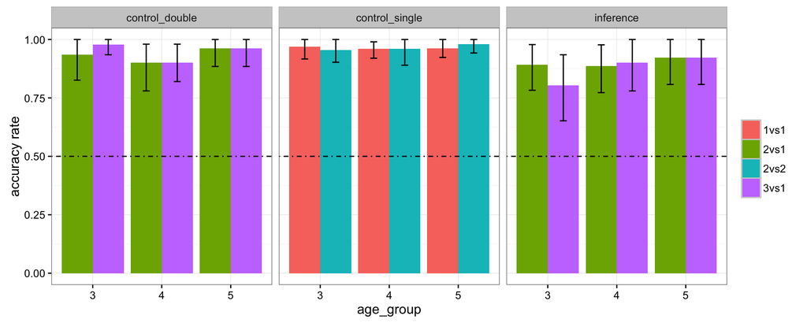

```r
mss <- d_ip %>%
  filter(trial_type != "practice" & age_group != "2" & age_group != "6") %>%
  group_by(age_group, trial_type, item_num, subid) %>%
  summarize(correct = mean(correct, na.rm=TRUE),
            rt = mean(rt, na.rm=TRUE))

# accuracy
ms <- mss %>%
  group_by(age_group, trial_type, item_num) %>%
  summarise(correct = mean(correct, na.rm=TRUE),
            cih = ci.high(correct, na.rm=TRUE),
            cil = ci.low(correct, na.rm=TRUE))

ggplot(ms,
       aes(fill=item_num, y=correct, x=age_group)) +
  geom_bar(position="dodge", stat="identity") +
  ylab("accuracy rate") +
  facet_grid(.~trial_type) +
  guides(fill=guide_legend(title=NULL)) +
  geom_hline(yintercept=.50,lty=4) +
  geom_errorbar(aes(ymin=correct-cil,ymax=correct+cih,width=.2),position=position_dodge(width = 0.90))
```

There does not seem to be any difference between the item numbers.

However, it is really striking that the accuracy rate on the iPad paradigm is much higher compared to eye-tracking paradigm, especially for the inference trials!

# Comparing control-double and inference trials across experiments

Here we compare only the control-double and inference trials across the eye-tracking and ipad paradigms.

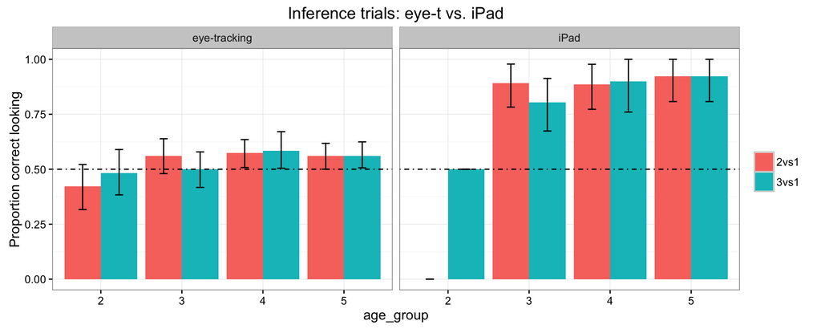

```r
# rearrange eye-tracking data
d_et_comp <- d_et %>%
  filter(t.crit > 0.78 & t.crit <= 3) %>%
  mutate(item_num = substring(expt, 4)) %>%
  select(item_num, age_group, trial_type, t.crit, correct, subid) %>%
  mutate(correct = as.factor(correct))
levels(d_et_comp$correct) <- c(0,1)
d_et_comp$correct <- as.numeric(as.character(d_et_comp$correct))

d_et_comp <- d_et_comp %>%
  mutate(trial_type = as.factor(trial_type)) %>%
  group_by(age_group, trial_type, item_num, subid) %>%
  summarise(correct = mean(correct, na.rm = TRUE))
levels(d_et_comp$trial_type) <- c("control_double", "control_single", "inference")
d_et_comp$expt <- "eye-tracking"

# rearrange iPad data

d_ip_comp <- d_ip %>%
  select(age_group, trial_type, item_num, correct, subid) %>%
  group_by(age_group, trial_type, item_num, subid) %>%
  summarise(correct = mean(correct, na.rm = TRUE))
d_ip_comp$expt <- "iPad"

# combine the two
d_comp <- rbind(d_et_comp, d_ip_comp)
d_comp <- d_comp %>%
  mutate_each(funs(factor), c(expt, age_group, trial_type, item_num, subid)) %>%
  filter(age_group != "6" & age_group != "adult") %>%
  droplevels()

# inference
d_comp_inf <- d_comp %>%
  filter(trial_type == "inference")
ms <- d_comp_inf %>%
  group_by(expt, age_group, item_num) %>%
  summarise(correct = mean(correct, na.rm = TRUE),
            cih = ci.high(correct, na.rm = TRUE),
            cil = ci.low(correct, na.rm = TRUE))

# bar graph
ggplot(ms,
       aes(fill=item_num, y=correct, x=age_group)) +
  geom_bar(position="dodge", stat="identity") +
  facet_wrap(~expt, ncol=4) +
  ylab("Proportion correct looking") +
  guides(fill=guide_legend(title=NULL)) +
  geom_hline(yintercept=.50,lty=4) +
  geom_errorbar(aes(ymin=correct-cil,ymax=correct+cih,width=.2),position=position_dodge(width = 0.90)) +
  ggtitle("Inference trials: eye-t vs. iPad")
```

(ignore 2-year-olds for iPad, there were only a couple of participants)

Is this true of other trials too (control-double and control-single)?

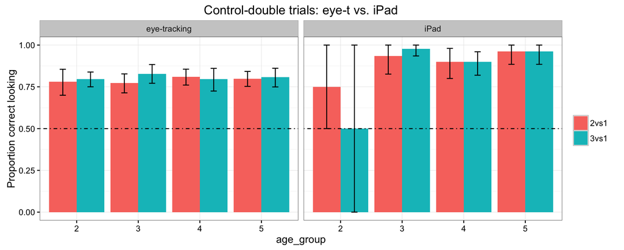

```r
# control-double
d_comp_cd <- d_comp %>%
  filter(trial_type == "control_double")
ms <- d_comp_cd %>%
  group_by(expt, age_group, item_num) %>%
  summarise(correct = mean(correct, na.rm = TRUE),
            cih = ci.high(correct, na.rm = TRUE),
            cil = ci.low(correct, na.rm = TRUE))

# bar graph
ggplot(ms,
       aes(fill=item_num, y=correct, x=age_group)) +
  geom_bar(position="dodge", stat="identity") +
  facet_wrap(~expt, ncol=4) +
  ylab("Proportion correct looking") +
  guides(fill=guide_legend(title=NULL)) +
  geom_hline(yintercept=.50,lty=4) +
  geom_errorbar(aes(ymin=correct-cil,ymax=correct+cih,width=.2),position=position_dodge(width = 0.90)) +
  ggtitle("Control-double trials: eye-t vs. iPad")
```

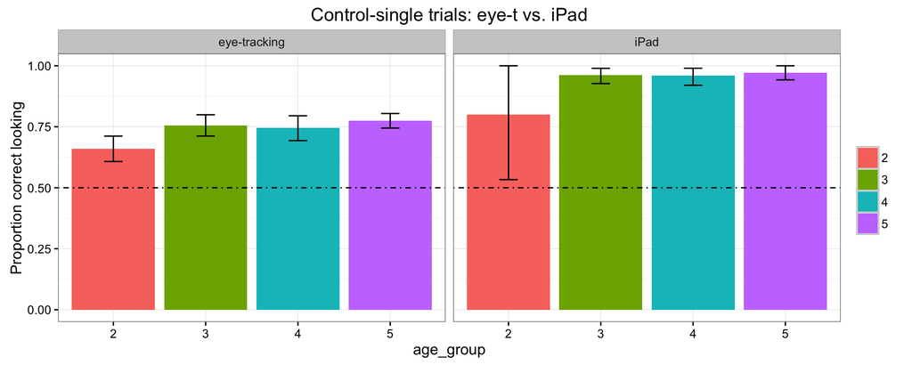

```r
# control-single
d_comp_cs <- d_comp %>%
  filter(trial_type == "control_single")
ms <- d_comp_cs %>%
  group_by(expt, age_group) %>%
  summarise(correct = mean(correct, na.rm = TRUE),
            cih = ci.high(correct, na.rm = TRUE),
            cil = ci.low(correct, na.rm = TRUE))

# bar graph
ggplot(ms,
       aes(fill=age_group, y=correct, x=age_group)) +
  geom_bar(position="dodge", stat="identity") +
  ylab("Proportion correct looking") +
  guides(fill=guide_legend(title=NULL)) +
  facet_grid(.~expt) +
  geom_hline(yintercept=.50,lty=4) +
  geom_errorbar(aes(ymin=correct-cil,ymax=correct+cih,width=.2),position=position_dodge(width = 0.90)) +
   ggtitle("Control-single trials: eye-t vs. iPad")
```

Yes – the difference is not as great as between inference trials in eye-tracking and iPad, but even on control trials children show greater accuracy rate.

# rt ana - on ipad

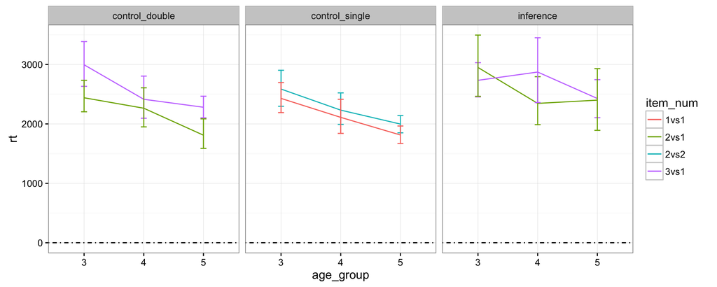

```r
mss <- d_ip %>%
  filter(trial_type != "practice" & age_group != "2" & age_group != "6") %>%
  group_by(age_group, trial_type, item_num, subid) %>%
  summarize(correct = mean(correct, na.rm=TRUE),
            rt = mean(rt, na.rm=TRUE))

ms <- mss %>%
  group_by(age_group, trial_type, item_num) %>%
  summarise(rt = mean(rt, na.rm = TRUE),
            cih = ci.high(rt, na.rm = TRUE),
            cil = ci.low(rt, na.rm = TRUE))

ggplot(ms,
       aes(color=item_num, y=rt, x=age_group)) +
  geom_line(aes(group=item_num)) +
  ylab("rt") +
  facet_grid(.~trial_type) +
  guides(fill=guide_legend(title=NULL)) +
  geom_hline(yintercept=.50,lty=4) +
  geom_errorbar(aes(ymin=rt-cil,ymax=rt+cih,width=.1))
```

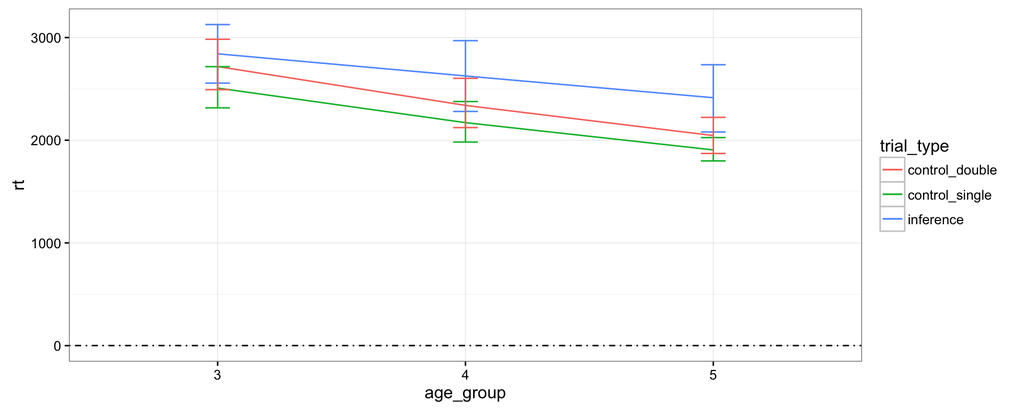

```r
ms <- mss %>%
  group_by(age_group, trial_type) %>%
  summarise(rt = mean(rt, na.rm = TRUE),
            cih = ci.high(rt, na.rm = TRUE),
            cil = ci.low(rt, na.rm = TRUE))

ggplot(subset(ms, trial_type != "practice"),
       aes(color=trial_type, y=rt, x=age_group)) +
  geom_line(aes(group=trial_type)) +
  ylab("rt") +
  guides(fill=guide_legend(title=NULL)) +
  geom_hline(yintercept=.50,lty=4) +
  geom_errorbar(aes(ymin=rt-cil,ymax=rt+cih,width=.1))
```

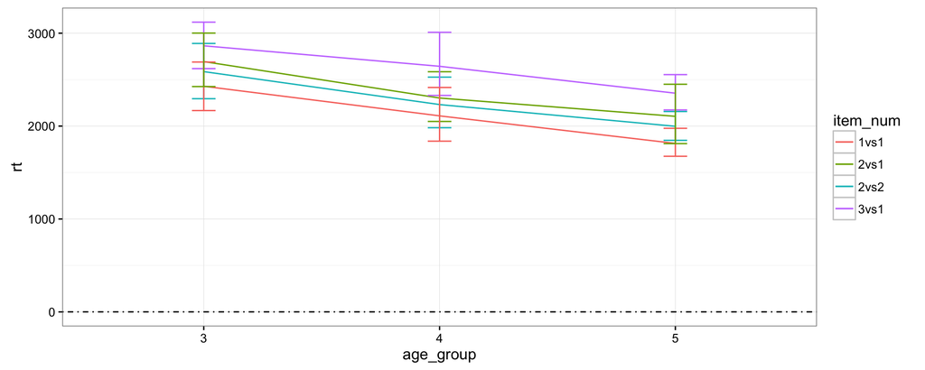

```r
# comparing across different number of items present
ms <- mss %>%
  group_by(age_group, item_num) %>%
  summarise(rt = mean(rt, na.rm = TRUE),
            cih = ci.high(rt, na.rm = TRUE),
            cil = ci.low(rt, na.rm = TRUE))

ggplot(ms,
       aes(color=item_num, y=rt, x=age_group)) +
  geom_line(aes(group=item_num)) +
  ylab("rt") +
  guides(fill=guide_legend(title=NULL)) +
  geom_hline(yintercept=.50,lty=4) +
  geom_errorbar(aes(ymin=rt-cil,ymax=rt+cih,width=.1))
```

RT on inference trial is generally higher, but not as much as might be expected from the difference in the effects seen in et vs. ipad.

RT on trials with more items is higher, which confirms that children do spend more time on trials with more things to look at before making a decision.

# rt ana - eye-tracking

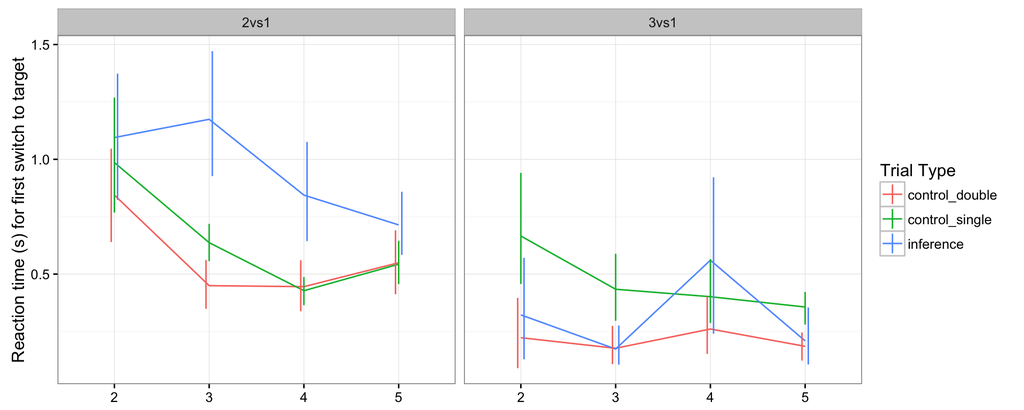

```r
mss_et <- d_et %>%
  filter(age_group != "adult" & age_group != "6") %>%
  filter(targetAtOnset == FALSE) %>%
  group_by(expt, age_group, trial_type, subid) %>%
  summarize(rt = mean(switch_t, na.rm=TRUE))

ms_et <- mss_et %>%
  mutate(expt = substring(expt, 4)) %>%
  group_by(expt, age_group, trial_type) %>%
  summarize(rt = mean(rt, na.rm=TRUE),
            cih = ci.high(rt, na.rm=TRUE),
            cil = ci.low(rt, na.rm=TRUE))
ms_et$trial_type <- as.factor(ms_et$trial_type)
levels(ms_et$trial_type) <- c("control_double", "control_single", "inference")

qplot(age_group, rt, group=trial_type, label=trial_type,
      colour=trial_type,
      geom="line",
      data=subset(ms_et, age_group != "1" & age_group != "Adults")) +
    geom_linerange(aes(ymin=rt-cil,ymax=rt+cih,width=.2),
                  position=position_dodge(width=.1)) +
  ylab("Reaction time (s) for first switch to target") +
  xlab(NULL) +
  scale_colour_discrete(name="Trial Type") +
  facet_grid(.~expt)
```

Compare ipad and et rt

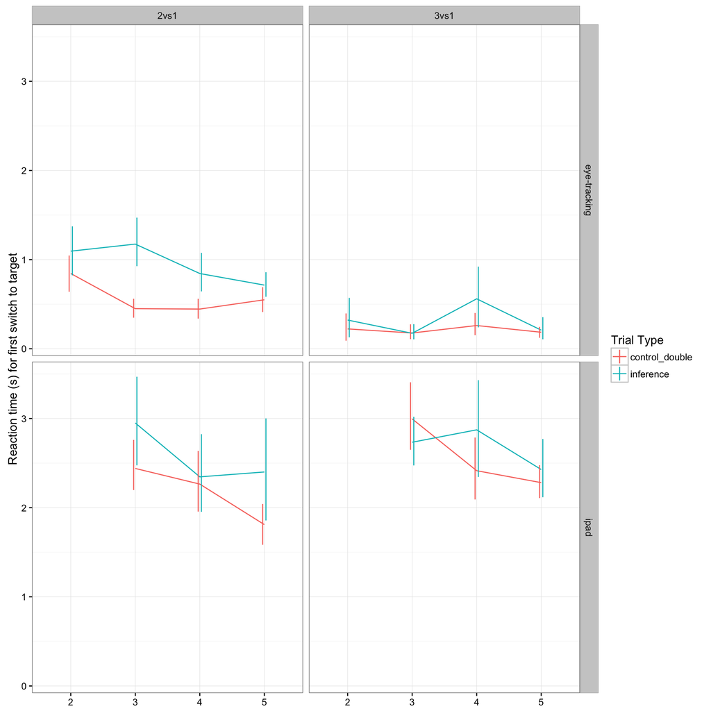

```r
# rearranging to compare ipad and et

#ipad data
mss_ip <- d_ip %>%
  filter(age_group != "2" & age_group != "6") %>%
  group_by(age_group, trial_type, item_num, subid) %>%
  summarize(correct = mean(correct, na.rm=TRUE),
            rt = mean(rt, na.rm=TRUE))

ms_ip <- mss_ip %>%
  group_by(age_group, trial_type, item_num) %>%
  summarize(rt = mean(rt, na.rm=TRUE),
            cih = ci.high(rt, na.rm=TRUE),
            cil = ci.low(rt, na.rm=TRUE)) %>%
  mutate(expt = "ipad") %>%
  mutate(rt = rt/1000,
         cih = cih/1000,
         cil = cil/1000)

#et data
ms_et <- ms_et %>%
  mutate(item_num = expt) %>%
  mutate(expt = "eye-tracking")

ms <- rbind(ms_et, ms_ip)
ms <- ms %>%
  filter(trial_type != "control_single" & trial_type != "practice") %>%
  mutate(expt = as.factor(expt),
         trial_type = as.factor(trial_type),
         age_group = as.factor(age_group),
         item_num = as.factor(item_num)
  )

qplot(age_group, rt, group=trial_type, label=trial_type,
      colour=trial_type,
      geom="line",
      data=ms) +
    geom_linerange(aes(ymin=rt-cil,ymax=rt+cih,width=.2),
                  position=position_dodge(width=.1)) +
  ylab("Reaction time (s) for first switch to target") +
  xlab(NULL) +
  scale_colour_discrete(name="Trial Type") +
  facet_grid(expt~item_num)
```